# Introduction to Seaborn Plots

Rajesh Majumder

April 18, 2023

The main idea of Seaborn is that it provides high-level commands to create a variety of plot types useful for statistical data exploration, and even some statistical model fitting.

## Installation of Seaborn

Install it using this command:(*write the command on the command python command prompt/ ANACONDA prompt*)

`pip install seaborn`

or

`conda install seaborn`

## Checking Seaborn Version

The version string is stored under `__version__` attribute.

```python
import seaborn as sns
print(sns.__version__)
```

```
0.11.2
```

```python
## Import matplotlib

import matplotlib.pyplot as plt
```

## Distribution plots

- `distplot`
- `jointplot`
- `pairplot`

## Data set

```python
df= sns.load_dataset("tips")
```

```python
df.head()
```

|  | total_bill | tip | sex | smoker | day | time | size |
| --- | --- | --- | --- | --- | --- | --- | --- |
| 0 | 16.99 | 1.01 | Female | No | Sun | Dinner | 2 |
| 1 | 10.34 | 1.66 | Male | No | Sun | Dinner | 3 |
| 2 | 21.01 | 3.50 | Male | No | Sun | Dinner | 3 |
| 3 | 23.68 | 3.31 | Male | No | Sun | Dinner | 2 |
| 4 | 24.59 | 3.61 | Female | No | Sun | Dinner | 4 |

```python
df.dtypes  ## Data types
```

```
total_bill     float64
tip            float64
sex           category
smoker        category
day           category
time          category
size             int64
dtype: object
```

## Correlation with Heatmap

A correlation heatmap uses colored cells, typically in a monochromatic scale, to show a 2D correlation matrix(table) between two discrete dimensions or event types, it is very important for EDA.

```python
df.corr()
```

|  | total_bill | tip | size |
| --- | --- | --- | --- |
| total_bill | 1.000000 | 0.675734 | 0.598315 |
| tip | 0.675734 | 1.000000 | 0.489299 |
| size | 0.598315 | 0.489299 | 1.000000 |

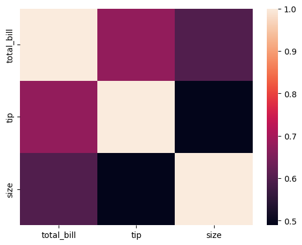

```python
## HeatMap

sns.heatmap(df.corr())
```

## Univariate Analysis

### Histogram And Kernel Density plot

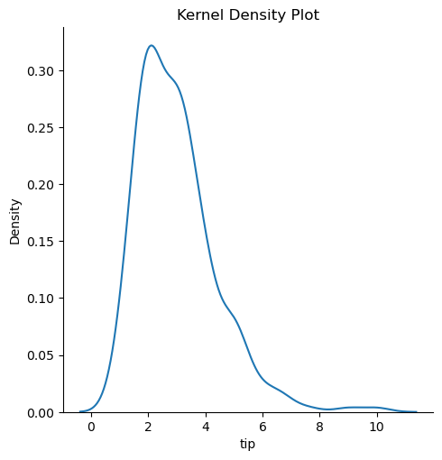

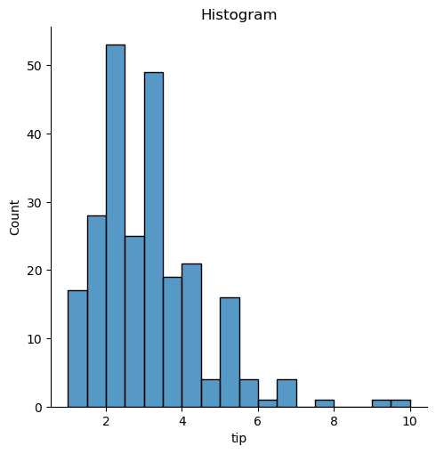

```python
sns.displot(df['tip'],kind='kde') ## Kernel Density
plt.title("Kernel Density Plot")

sns.displot(df['tip']) ## Histogram
plt.title("Histogram")
```

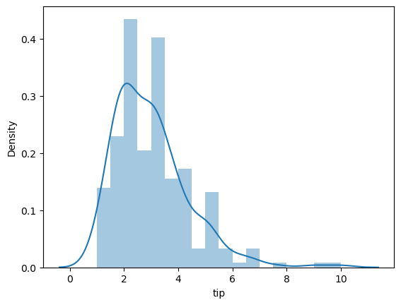

```python
## Overlapping KD on Histogram using sns.distplot()

sns.distplot(df['tip'])
```

### Two Dimensional Distribution Plot

#### 1. Simple Histograms & KD Plot

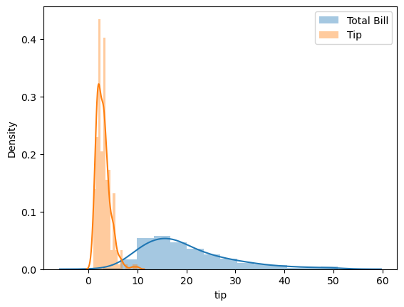

```python
sns.distplot(df['total_bill'],label="Total Bill")
sns.distplot(df['tip'],label="Tip")
plt.legend()
```

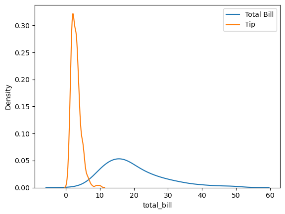

```python
sns.kdeplot(df.iloc[:,0],label="Total Bill")
sns.kdeplot(df.iloc[:,1],label="Tip")
plt.legend()
```

## Join Plot

It plots X-Y scatter plot along with Merginal distributions (Hist./KD) of X & Y.

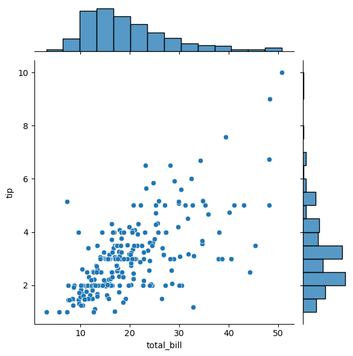

```python
sns.jointplot(x='total_bill',y='tip',data=df)
```

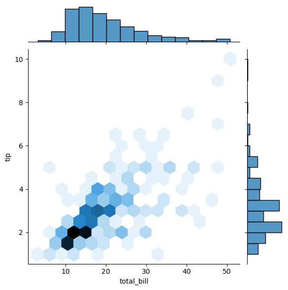

```python
sns.jointplot(x='total_bill',y='tip',data=df,kind='hex') ## kind='hex' draws Hexagon
```

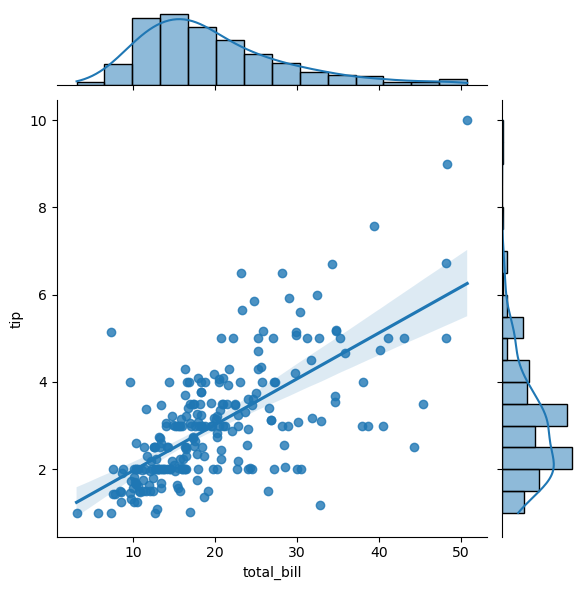

```python
sns.jointplot(x='total_bill',y='tip',data=df,kind='reg') ## kind='reg' draws regression Line
```

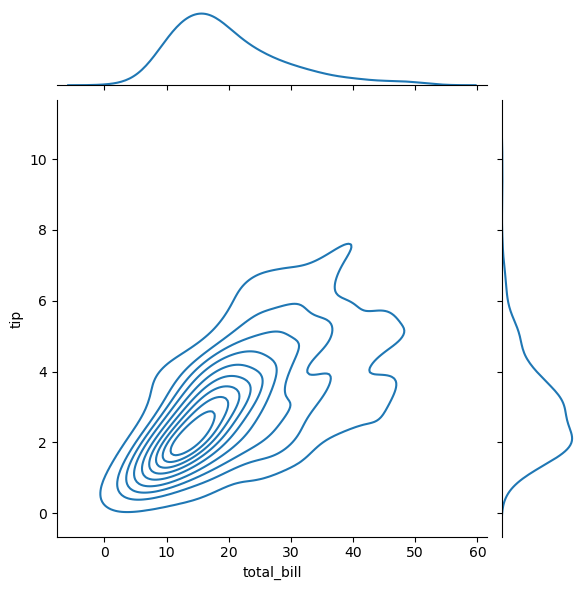

```python
sns.jointplot(x='total_bill',y='tip',data=df,kind='kde') ## kind='kde' draws Kernel Density
```

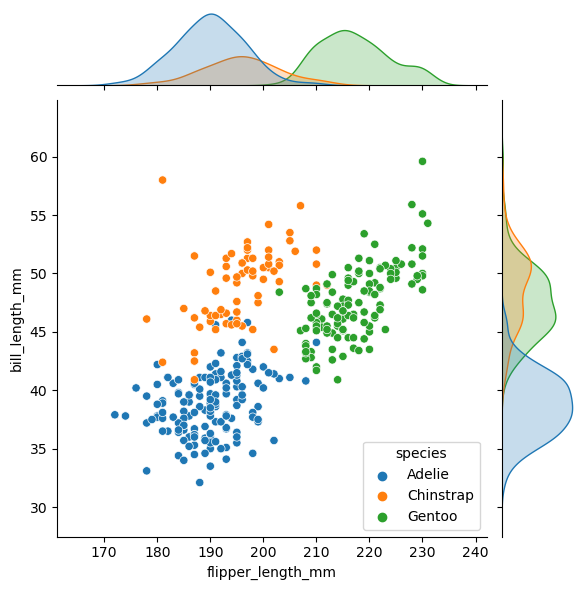

```python
penguins = sns.load_dataset("penguins")
sns.jointplot(data=penguins, x="flipper_length_mm", y="bill_length_mm", hue="species")
```

## Pair Plot

A pair plot is also known as a scatterplot, in which one variable in the same data row is mattached with another variable's value,like this Pairs plots are just elaborations on this, showing all variables paired with all the other variables.

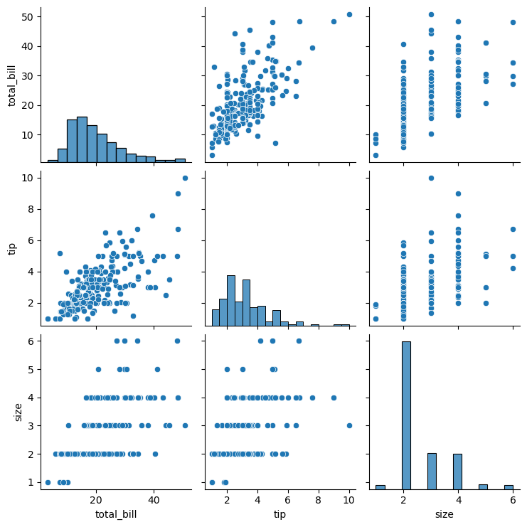

```python
sns.pairplot(df)
```

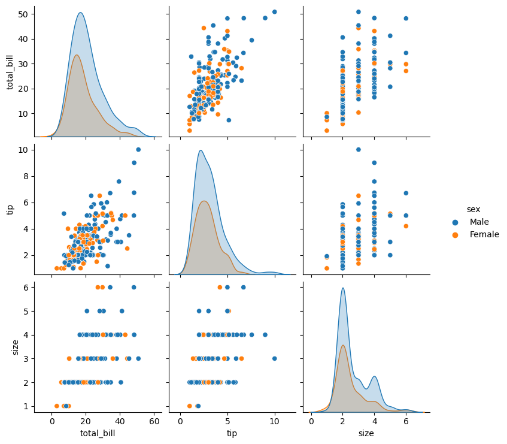

```python
sns.pairplot(df,hue="sex") ## Group By Sex
```

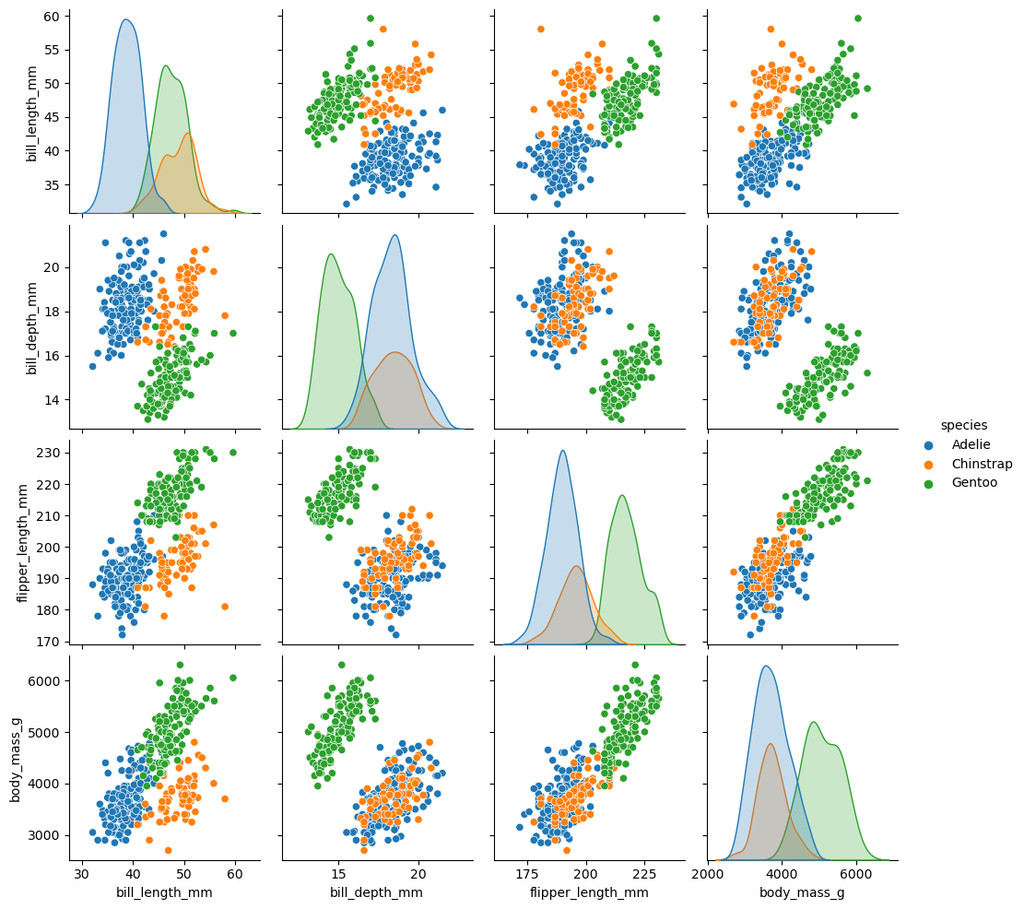

```python
sns.pairplot(data=penguins, hue="species")
```

## Categorical Plors

- Boxplot
- Countclot
- barplot

### 1. Boxplot

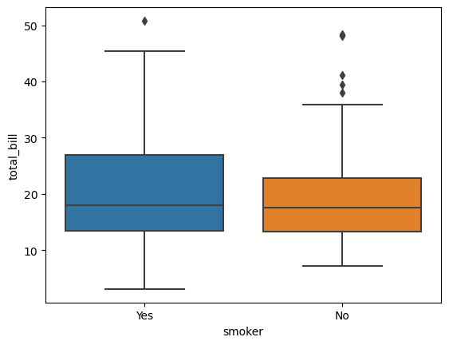

```python
sns.boxplot(x='smoker',y='total_bill',data=df)
```

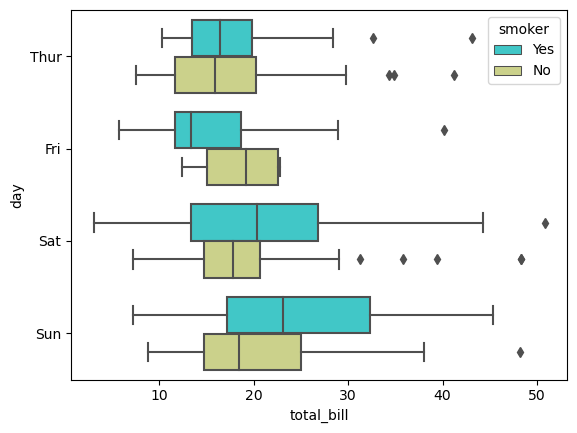

```python
sns.boxplot(x='total_bill',y='day',hue='smoker',data=df,palette='rainbow')
```

### 2. Countplot

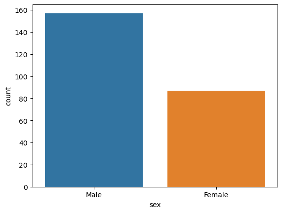

```python
sns.countplot(x='sex',data=df)
```

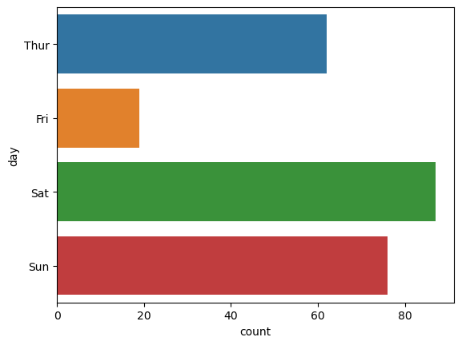

```python
sns.countplot(y='day',data=df) ## Horizontal Countplot
```

### 3. Barplot

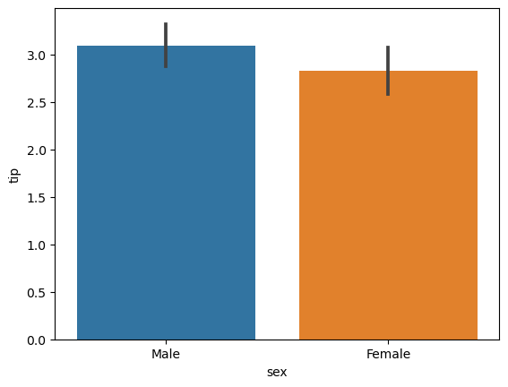

```python
sns.barplot(x='sex',y='tip',data=df)
```

Further Reading: https://seaborn.pydata.org/tutorial/introduction.html